# Somatic SNP filtering

Ranjit Kumar

> Project details: Freebayes was used to perform varint calling on tumor-matched normal samples. We have 88 vcf files, converted to tab delimted form using GATK. We added annoatations from 1000 genome, COSMIC and SNPeff. The objective is to filter germline variants from somatic ones. Ignore NF(normal frequency in further analysis).

> This notebook GF1b contains exploratory analysis of the dataset with intent to dectect any outliers.

##### A. Load the data from previous notebook

```r
load('all_vcf2.RData')
```

##### B1. Checking variant counts for each sample

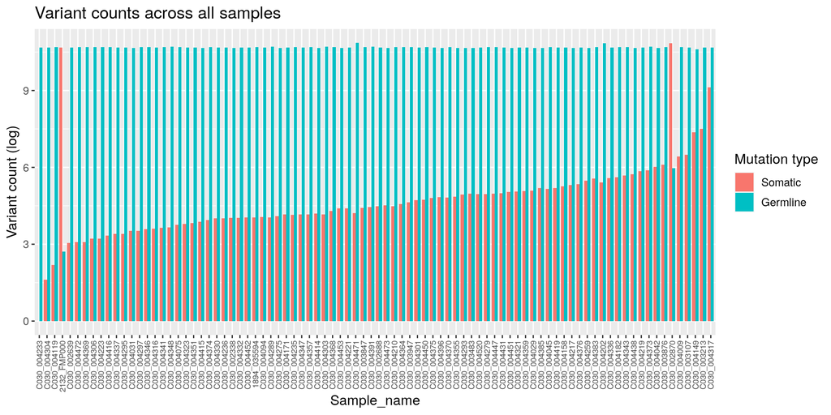

```r
all_vcf2 %>%
  group_by(Sample_name, Mut_type) %>%
  summarise(count=n())  %>%
  arrange(count)  %>%
  ggplot(aes(x = reorder(Sample_name, log(count)), y = log(count), fill = as.factor(Mut_type))) +
  geom_bar(stat = "identity", position = "dodge",  width = 0.8) +
  theme(axis.text.x = element_text(angle = 90, vjust = 0.5, hjust=1, size=7)) +
  theme(text = element_text(size=12)) +
  scale_fill_discrete(name = "Mutation type", labels = c("Somatic", "Germline")) +
  labs(title="Variant counts across all samples", x ="Sample_name", y = "Variant count (log)")
```

Note: Looks like two samples (2132_FMP000 ,C030_002870) have abnormally high somatic count indicating sample swap or contamination.

##### B2. Exploring TF distribution

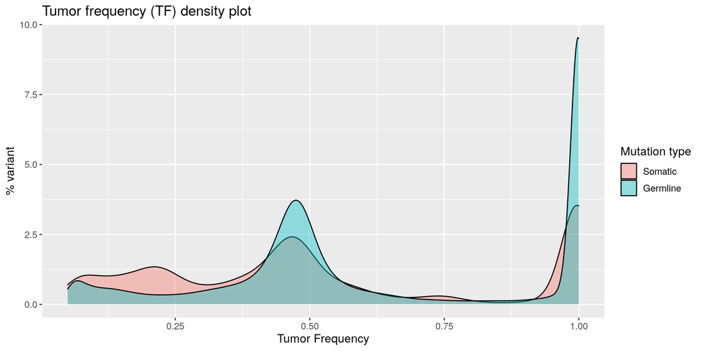

```r
all_vcf2 %>%
  ggplot(aes(TF,fill = factor(Mut_type))) +
  geom_density(alpha=0.4) +
  theme(text = element_text(size=12)) +
  scale_fill_discrete(name = "Mutation type", labels = c("Somatic", "Germline")) +
  labs(title="Tumor frequency (TF) density plot ", x ="Tumor Frequency", y = "% variant")
```

Note: The TF distribution does not look natural for somatic given median at 0.5.

##### B3. Checking TF mean (tumor frequency mean) for each sample

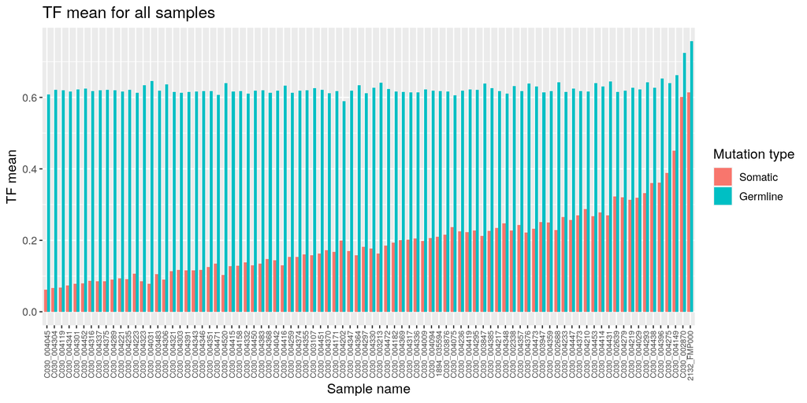

```r
  all_vcf2 %>%
  group_by(Sample_name,Mut_type) %>%
  summarise_at(vars(TF),list(mean=mean))  %>%
  arrange(desc(mean))  %>%
  ggplot(aes(x = reorder(Sample_name, mean), y = mean, fill = as.factor(Mut_type) )) +
  geom_bar(stat = "identity", position = "dodge",  width = 0.8) +
  theme(axis.text.x = element_text(angle = 90, vjust = 0.5, hjust=1, size=7)) +
  theme(text = element_text(size=12)) +
  scale_fill_discrete(name = "Mutation type", labels = c("Somatic", "Germline")) +
  labs(title="TF mean for all samples", x ="Sample name", y = "TF mean")
```

##### B4. Checking 1000 genome distribution for each sample

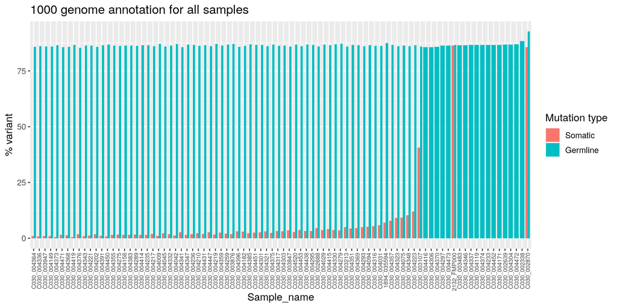

```r
  all_vcf2 %>%
  mutate(is1000g = ifelse( X1000g_AF > 0.005, 1, 0)) %>%
  group_by(Sample_name,Mut_type,is1000g) %>%
  summarise(count=n()) %>%
  mutate(percent = paste0(round(count/sum(count)*100,2),"%"))  %>%
  filter(is1000g == 1) %>%
  ggplot(aes(x = reorder(Sample_name, as.numeric(sub("%", "", percent))), y = as.numeric(sub("%", "", percent)), fill = as.factor(Mut_type) )) +
  geom_bar(stat = "identity", position = "dodge",  width = 0.8) +
  theme(axis.text.x = element_text(angle = 90, vjust = 0.5, hjust=1, size=7)) +
  theme(text = element_text(size=12)) +
  scale_fill_discrete(name = "Mutation type", labels = c("Somatic", "Germline")) +
  labs(title="1000 genome annotation for all samples ", x ="Sample_name", y = "% variant")
```

##### B5. So removing two outliers and saving it as all_vcf3

```r
all_vcf3 <-
  all_vcf2 %>%
  filter(!(Sample_name  %in% c("2132_FMP000", "C030_002870")))

save(all_vcf3, file = "all_vcf3.RData")
```

##### To buypass knitting all the document from start while developing.

```r
knitr::opts_chunk$set(cache = TRUE, warning = FALSE,
                      message = FALSE, cache.lazy = FALSE)
render("GF1b.Rmd")
# opens at http://172.28.23.82/files/dataset_14oct2/GF1b.html
```